# Transcriptomics in R practical (Summary report) | UVic-UCC, 2023-24

Vadim Leonov

2024-01-18

# 1 **Loading the chosen dataset**

```r
#Data set presentation
gseid<-"GSE162729" #RNA-seq GPL11154    Illumina HiSeq 2000 (Homo sapiens)
gse <- getGEO(gseid, GSEMatrix=TRUE)[[1]]
```

**Comment:** GSE162729 includes a dataset of 12 samples, presenting gene expression profiles for macrophages infected with distinct strains of Mycobacterium tuberculosis (BCG, H37Rv, and H37Ra), serving as three conditions for downstream analysis. The study, conducted by Pu and colleagues (Pu et al., 2021), aimed to explore global transcriptome changes in macrophages during infection with various strains of tuberculosis.

```r
pheno <- pData(gse)

pheno <- pData(gse)[, c('title', 'characteristics_ch1.1')]
colnames(pheno) <- c("Condition", "Description")

phenoN <- data.frame(
  sampleGEO = rownames(pheno),
  Condition = sub("Condition: (.*)", "\\1", pheno$Condition),
  Description = sub("Description: (.*)", "\\1", pheno$Description)
)


cond <- c(rep('Ctr', 3), rep('H37Rv', 3),  rep('H37Ra', 3), rep('BCG', 3))

phenoN$cond<-cond

phenoN$sampleName <- paste(phenoN$Condition,phenoN$Description, sep="_")
row.names(phenoN)=phenoN$sampleName

dim(phenoN)
```

```
## [1] 12  5
```

```r
phenoN
```

```
##                                                                               sampleGEO
## Control 1_treament: treated with PMA for 24h                                 GSM4958123
## Control 2_treament: treated with PMA for 24h                                 GSM4958124
## Control 3_treament: treated with PMA for 24h                                 GSM4958125
## H37Rv 1_treament: treated with PMA for 24h and infected H37Rv strain for 24h GSM4958126
## H37Rv 2_treament: treated with PMA for 24h and infected H37Rv strain for 24h GSM4958127
## H37Rv 3_treament: treated with PMA for 24h and infected H37Rv strain for 24h GSM4958128
## H37Ra 1_treament: treated with PMA for 24h and infected H37Ra strain for 24h GSM4958129
## H37Ra 2_treament: treated with PMA for 24h and infected H37Ra strain for 24h GSM4958130
## H37Ra 3_treament: treated with PMA for 24h and infected H37Ra strain for 24h GSM4958131
## BCG 1_treament: treated with PMA for 24h and infected BCG strain for 24h     GSM4958132
## BCG 2_treament: treated with PMA for 24h and infected BCG strain for 24h     GSM4958133
## BCG 3_treament: treated with PMA for 24h and infected BCG strain for 24h     GSM4958134
##                                                                              Condition
## Control 1_treament: treated with PMA for 24h                                 Control 1
## Control 2_treament: treated with PMA for 24h                                 Control 2
## Control 3_treament: treated with PMA for 24h                                 Control 3
## H37Rv 1_treament: treated with PMA for 24h and infected H37Rv strain for 24h   H37Rv 1
## H37Rv 2_treament: treated with PMA for 24h and infected H37Rv strain for 24h   H37Rv 2
## H37Rv 3_treament: treated with PMA for 24h and infected H37Rv strain for 24h   H37Rv 3
## H37Ra 1_treament: treated with PMA for 24h and infected H37Ra strain for 24h   H37Ra 1
## H37Ra 2_treament: treated with PMA for 24h and infected H37Ra strain for 24h   H37Ra 2
## H37Ra 3_treament: treated with PMA for 24h and infected H37Ra strain for 24h   H37Ra 3
## BCG 1_treament: treated with PMA for 24h and infected BCG strain for 24h         BCG 1
## BCG 2_treament: treated with PMA for 24h and infected BCG strain for 24h         BCG 2
## BCG 3_treament: treated with PMA for 24h and infected BCG strain for 24h         BCG 3
##                                                                                                                                       Description
## Control 1_treament: treated with PMA for 24h                                                                   treament: treated with PMA for 24h
## Control 2_treament: treated with PMA for 24h                                                                   treament: treated with PMA for 24h
## Control 3_treament: treated with PMA for 24h                                                                   treament: treated with PMA for 24h
## H37Rv 1_treament: treated with PMA for 24h and infected H37Rv strain for 24h treament: treated with PMA for 24h and infected H37Rv strain for 24h
## H37Rv 2_treament: treated with PMA for 24h and infected H37Rv strain for 24h treament: treated with PMA for 24h and infected H37Rv strain for 24h
## H37Rv 3_treament: treated with PMA for 24h and infected H37Rv strain for 24h treament: treated with PMA for 24h and infected H37Rv strain for 24h
## H37Ra 1_treament: treated with PMA for 24h and infected H37Ra strain for 24h treament: treated with PMA for 24h and infected H37Ra strain for 24h
## H37Ra 2_treament: treated with PMA for 24h and infected H37Ra strain for 24h treament: treated with PMA for 24h and infected H37Ra strain for 24h
## H37Ra 3_treament: treated with PMA for 24h and infected H37Ra strain for 24h treament: treated with PMA for 24h and infected H37Ra strain for 24h
## BCG 1_treament: treated with PMA for 24h and infected BCG strain for 24h       treament: treated with PMA for 24h and infected BCG strain for 24h
## BCG 2_treament: treated with PMA for 24h and infected BCG strain for 24h       treament: treated with PMA for 24h and infected BCG strain for 24h
## BCG 3_treament: treated with PMA for 24h and infected BCG strain for 24h       treament: treated with PMA for 24h and infected BCG strain for 24h
##                                                                               cond
```

[output cut: 10 more lines]

```
## BCG 2_treament: treated with PMA for 24h and infected BCG strain for 24h       BCG
## BCG 3_treament: treated with PMA for 24h and infected BCG strain for 24h       BCG
##                                                                                                                                                sampleName
## Control 1_treament: treated with PMA for 24h                                                                 Control 1_treament: treated with PMA for 24h
## Control 2_treament: treated with PMA for 24h                                                                 Control 2_treament: treated with PMA for 24h
## Control 3_treament: treated with PMA for 24h                                                                 Control 3_treament: treated with PMA for 24h
## H37Rv 1_treament: treated with PMA for 24h and infected H37Rv strain for 24h H37Rv 1_treament: treated with PMA for 24h and infected H37Rv strain for 24h
## H37Rv 2_treament: treated with PMA for 24h and infected H37Rv strain for 24h H37Rv 2_treament: treated with PMA for 24h and infected H37Rv strain for 24h
## H37Rv 3_treament: treated with PMA for 24h and infected H37Rv strain for 24h H37Rv 3_treament: treated with PMA for 24h and infected H37Rv strain for 24h
## H37Ra 1_treament: treated with PMA for 24h and infected H37Ra strain for 24h H37Ra 1_treament: treated with PMA for 24h and infected H37Ra strain for 24h
## H37Ra 2_treament: treated with PMA for 24h and infected H37Ra strain for 24h H37Ra 2_treament: treated with PMA for 24h and infected H37Ra strain for 24h
## H37Ra 3_treament: treated with PMA for 24h and infected H37Ra strain for 24h H37Ra 3_treament: treated with PMA for 24h and infected H37Ra strain for 24h
## BCG 1_treament: treated with PMA for 24h and infected BCG strain for 24h         BCG 1_treament: treated with PMA for 24h and infected BCG strain for 24h
## BCG 2_treament: treated with PMA for 24h and infected BCG strain for 24h         BCG 2_treament: treated with PMA for 24h and infected BCG strain for 24h
## BCG 3_treament: treated with PMA for 24h and infected BCG strain for 24h         BCG 3_treament: treated with PMA for 24h and infected BCG strain for 24h
```

```r
gseSupp <- getGEOSuppFiles(gseid, makeDirectory = TRUE)
setwd(file.path(wd,gseid))

countsO <- read_excel("GSE162729_Processed_data.xlsx") #manually load xsl file

countsM<-as.matrix(countsO[,c("Control_1 Read Count","Control_2 Read Count","Control_3 Read Count","H37Rv_1 Read Count","H37Rv_2 Read Count", "H37Rv_3 Read Count",     "H37Ra_1 Read Count",     "H37Ra_2 Read Count",     "H37Ra_3 Read Count",   "BCG_1 Read Count", "BCG_2 Read Count",      "BCG_3 Read Count")])

#we assume the order is the same
rownames(countsM) <- countsO$'Gene Symbol'

countsM[is.na(countsM)] = 0 #all NA values are replaced now by zero in countsM
```

**Comment:** The transcriptomic dataset from the GSE162729 (www.ncbi.nlm.nih.gov) series was processed in R using the GEOquery package from Bioconductor. Upon setting the GSE ID, the getGEO function retrieved the dataset, yielding a list where the initial element contains expression data stored as an eSet. Phenotype data associated with the expression data was organized and formatted, leading to the creation of a new dataframe, phenoN, to store sample information with assigned conditions.

Supplementary files were obtained using getGEOSuppFiles, and the working directory was adjusted accordingly. Expression data from the “GSE162729_Processed_data.xlsx” file was read and processed manually, resulting in a matrix (countsM) with specific columns representing sample read counts. This thorough approach ensures the successful processing of the dataset, laying the foundation for subsequent analyses and interpretation.

Note: The original dataset contained a significant number of missing values in expression data, necessitating their replacement with zero. Despite an exhaustive review, we could not identify a conclusive explanation for the prevalence of missing values, even after consulting the original publication (Pu et al., 2021). The presence of these missing values could be attributed to various factors, including technical issues during sample preparation, RNA extraction, library preparation, or sequencing, as well as biological variability and low expression levels of specific genes. The decision to replace missing values with zeros is a common practice, assuming that the absence of a signal corresponds to zero expression. It is crucial to acknowledge the potential impact of such data preprocessing steps on downstream analyses and interpretations.

# 2 **Exploration and filtration**

```r
#Exploration
sampleT <- apply(countsM, 2, sum)/10^6
sampleT
```

```
## Control_1 Read Count Control_2 Read Count Control_3 Read Count
##             17.62610             17.98040             17.52984
##   H37Rv_1 Read Count   H37Rv_2 Read Count   H37Rv_3 Read Count
##             17.11775             17.26883             12.66287
##   H37Ra_1 Read Count   H37Ra_2 Read Count   H37Ra_3 Read Count
##             17.16061             16.97747             16.84522
##     BCG_1 Read Count     BCG_2 Read Count     BCG_3 Read Count
##             17.57998             16.82489             16.61517
```

```r
range(sampleT)
```

```
## [1] 12.66287 17.98040
```

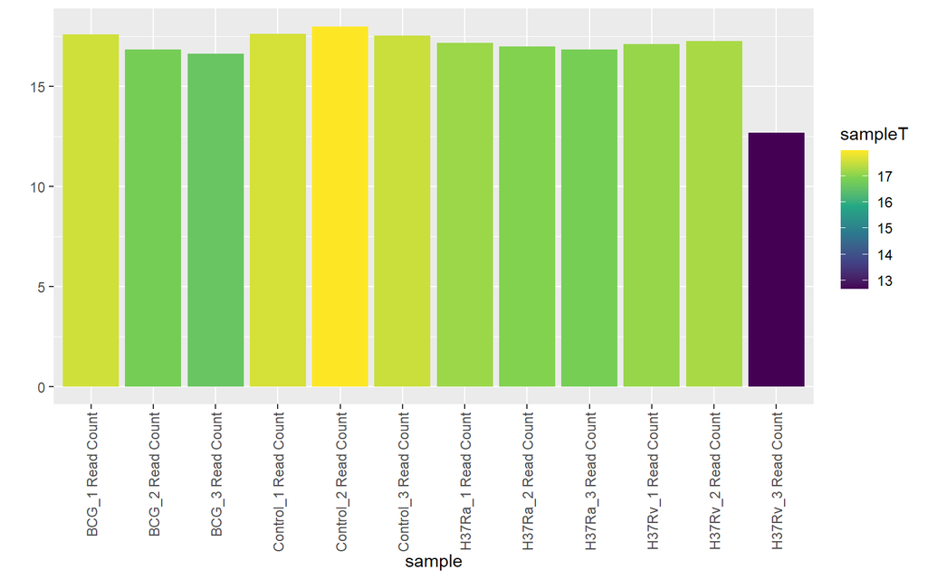

```r
sampleTDF <- data.frame(sample=names(sampleT), total=sampleT)

p <- ggplot(aes(x=sample, y=sampleT, fill=sampleT), data=sampleTDF) +
  geom_bar(stat="identity") +
  theme(axis.text.x = element_text(angle = 90, vjust = 0.5, hjust=1)) +
  ylab("") +
  scale_fill_viridis_c(option = "D")

p
```

```r
#Filtering
dim(countsM)
```

```
## [1] 19965    12
```

```r
keep <- rowSums(countsM > 10) >= 6# at least 6 samples have 10 reads per gene
countsF <- countsM[keep,]
dim(countsF)
```

```
## [1] 13196    12
```

**Comment:** The exploratory analysis of the gene expression dataset involved the calculation of sample totals, represented by the variable sampleT. This metric was computed by summing the counts for each sample and normalizing to a million reads. The range of sample totals was then assessed, revealing the variability in the overall expression levels across the samples. The results were organized into a dataframe, sampleTDF, capturing sample names and their corresponding total counts. A bar plot visualization was generated using ggplot2, depicting the distribution of sample totals. Most samples have almost equal read counts (around 16-17), the darker color for “H37Rv_3 Read Count” corresponds to the lowest number of read counts (around 13) for the sample. In the filtering stage of the gene expression analysis, the initial dataset, represented by a matrix countsM with dimensions 19965x12, was subjected to a rigorous filtering criterion. Genes were retained if they demonstrated a minimum threshold of 10 reads in at least 6 samples since we have 12 samples and 3 conditions to ensure that genes are consistently expressed across a reasonable subset of conditions. The filtering operation resulted in a refined dataset, countsF, with reduced dimensions of 13196x12. This filtration process ensures a focus on genes that exhibit a more consistent and substantial expression across multiple samples, streamlining the dataset for subsequent analyses.

# 3 **Normalization**

**1. Gene length**

[output not shown]

```
##      biomart               version
## 1      genes      Ensembl Genes 75
## 2       snps  Ensembl Variation 75
## 3 regulation Ensembl Regulation 75
## 4       vega               Vega 55
```

```
##                    name           description         page
## 1       ensembl_gene_id       Ensembl Gene ID feature_page
## 2 ensembl_transcript_id Ensembl Transcript ID feature_page
## 3    ensembl_peptide_id    Ensembl Protein ID feature_page
## 4       ensembl_exon_id       Ensembl Exon ID feature_page
## 5           description           Description feature_page
## 6       chromosome_name       Chromosome Name feature_page
```

```
##                      name                                     description
## 99        ensembl_gene_id       Ensembl Gene ID(s) [e.g. ENSG00000139618]
## 100 ensembl_transcript_id Ensembl Transcript ID(s) [e.g. ENST00000380152]
## 101    ensembl_peptide_id    Ensembl protein ID(s) [e.g. ENSP00000369497]
## 102       ensembl_exon_id       Ensembl exon ID(s) [e.g. ENSE00001508081]
```

```
##                name     description         page
## 7    start_position Gene Start (bp) feature_page
## 8      end_position   Gene End (bp) feature_page
## 146  start_position Gene Start (bp)    structure
## 147    end_position   Gene End (bp)    structure
## 187  start_position Gene Start (bp)     homologs
## 188    end_position   Gene End (bp)     homologs
## 1044 start_position Gene Start (bp)          snp
## 1045   end_position   Gene End (bp)          snp
## 1106 start_position Gene Start (bp)    sequences
## 1107   end_position   Gene End (bp)    sequences
```

```
##            name description      page
## 157  cds_length  CDS Length structure
## 1122 cds_length  CDS Length sequences
```

```
##                name     description         page
## 7    start_position Gene Start (bp) feature_page
## 8      end_position   Gene End (bp) feature_page
## 146  start_position Gene Start (bp)    structure
## 147    end_position   Gene End (bp)    structure
## 187  start_position Gene Start (bp)     homologs
## 188    end_position   Gene End (bp)     homologs
## 1044 start_position Gene Start (bp)          snp
## 1045   end_position   Gene End (bp)          snp
## 1106 start_position Gene Start (bp)    sequences
## 1107   end_position   Gene End (bp)    sequences
```

```r
gensInfo<-getBM(attributes=c("hgnc_symbol","chromosome_name","start_position","end_position"),
                filters=c("hgnc_symbol"),
                values=list(rownames(countsF)), mart=ensembl75)

gensInfo$length <- gensInfo$end_position - gensInfo$start_position
range(gensInfo$length)
```

```
## [1]      26 2304637
```

```r
dim(gensInfo)
```

```
## [1] 13965     5
```

```r
table(duplicated(gensInfo$hgnc_symbol))
```

```
##
## FALSE  TRUE
## 12460  1505
```

```r
# choose the setdiff function from the base package
setdiff_base <- base::setdiff

length(setdiff_base(rownames(countsF), gensInfo$hgnc_symbol))
```

```
## [1] 735
```

```r
countsFDF <- data.frame(ID=rownames(countsF),countsF)
countsFInfo <- right_join(countsFDF, gensInfo, by=c("ID"="hgnc_symbol"))
countsFInfo <- countsFInfo[!duplicated(countsFInfo$ID),] #after having checked duplications, just keep first result

any(is.na(countsFInfo[, c("Control_1.Read.Count","Control_2.Read.Count","Control_3.Read.Count","H37Rv_1.Read.Count","H37Rv_2.Read.Count", "H37Rv_3.Read.Count",     "H37Ra_1.Read.Count",     "H37Ra_2.Read.Count",     "H37Ra_3.Read.Count",   "BCG_1.Read.Count", "BCG_2.Read.Count",      "BCG_3.Read.Count")]))
```

```
## [1] TRUE
```

```r
countsFInfo[is.na(countsFInfo)] <- 0  # Replace NAs with zeros as a simple approach
head(countsFInfo)
```

```
##       ID Control_1.Read.Count Control_2.Read.Count Control_3.Read.Count
## 1 SLC9B1                42.49                79.38                77.79
## 2 ARNTL2               681.74               731.37               708.10
## 3   API5               219.04               205.64               202.37
## 4   CD36              1525.00              1584.00              1500.00
## 5 TMEM8B               118.00               129.00               151.00
## 6 HEXIM2               102.22                95.83               124.39
##   H37Rv_1.Read.Count H37Rv_2.Read.Count H37Rv_3.Read.Count H37Ra_1.Read.Count
## 1              66.71              47.95              33.19              58.10
## 2             625.18             668.32             289.86             369.38
## 3             705.71             378.99             176.42             226.47
## 4             976.00            1088.00             581.00             660.00
## 5             128.00              87.00             123.00             166.00
## 6              84.15              55.34              58.00              87.14
##   H37Ra_2.Read.Count H37Ra_3.Read.Count BCG_1.Read.Count BCG_2.Read.Count
## 1              98.32              86.56            57.40            70.22
## 2             397.77             415.26           524.94           521.74
## 3             731.25             730.36           233.80           489.31
## 4             716.00             984.00           899.00          1141.00
## 5             175.00             122.49           161.00           172.00
## 6              60.78              81.89            89.02            85.89
##   BCG_3.Read.Count chromosome_name start_position end_position length
## 1            38.49               4      103806205    103940896 134691
## 2           497.15              12       27485787     27576241  90454
## 3           267.09              11       43333513     43366079  32566
## 4          1023.00               7       79998891     80308593 309702
## 5           173.00               9       35814448     35854844  40396
## 6            88.74              17       43238067     43247407   9340
```

**Comment:** To normalize using FPKM, and TPM we need the gene length. TMM does not directly incorporate gene length into its normalization strategy. Instead, TMM focuses on estimating a scaling factor that can be applied to each sample to make their library sizes comparable. Normalizing gene expression data by gene length is a common step in RNA-seq analysis. The rationale behind this normalization is to account for the differences in the lengths of genes when comparing their expression levels. The number of reads obtained for a gene in RNA-seq experiments is affected by both the expression level of the gene and the gene’s length.

Overall, the gene lengths range from 26 to 2304637, gensInfo has 13965 rows and 5 columns, each row corresponds to information about a specific gene, and the columns include various attributes associated with each gene. In the countsF matrix is 735 genes whose names are not found in the hgnc_symbol column of the gensInfo data frame. The presence of duplicated genes (1505) in the dataset might be due to multiple transcripts or splicing variants for some genes, leading to different entries in the dataset with the same HGNC symbol.

Despite the fact that TPM is more popular to apply for normalization here for educational purposes we used FPKM, TMM and TPM. Additionally, TMM is suitable for comparing among the samples that we will use in downstream analysis for hierarchical clustering and PCA.

**2. FPKM**

```r
#step 1: normalize for read depth and multiply by million
readD <- apply(countsFInfo[,2:13], 2, function(x) x / sum(x) * 10^6)

#step 2. scale by gene length and multiply by thousand
countsFPKM <- readD / countsFInfo$length * 10^3

head(countsFPKM)
```

```
##   Control_1.Read.Count Control_2.Read.Count Control_3.Read.Count
## 1           0.01840394           0.03370672           0.03388152
## 2           0.43969710           0.46243776           0.45924508
## 3           0.39239333           0.36114957           0.36455193
## 4           0.28726878           0.29251968           0.28413514
## 5           0.17041438           0.18263974           0.21928871
## 6           0.63848633           0.58681139           0.78129723
##   H37Rv_1.Read.Count H37Rv_2.Read.Count H37Rv_3.Read.Count H37Ra_1.Read.Count
## 1         0.02980706         0.02123655         0.02001388         0.02583341
## 2         0.41595280         0.44074836         0.26026943         0.24456243
## 3         1.30415319         0.69422038         0.43999328         0.41647641
## 4         0.18965861         0.20956508         0.15236835         0.12762744
## 5         0.19069459         0.12847390         0.24730301         0.24610128
## 6         0.54221809         0.35344863         0.50436363         0.55874651
##   H37Ra_2.Read.Count H37Ra_3.Read.Count BCG_1.Read.Count BCG_2.Read.Count
## 1         0.04422743         0.03925371       0.02495372       0.03190398
## 2         0.26643586         0.28041056       0.33981598       0.35297914
## 3         1.36047289         1.36985500       0.42037995       0.91948014
## 4         0.14007397         0.19406764       0.16997208       0.22545731
## 5         0.26247510         0.18520995       0.23337236       0.26056301
## 6         0.39427773         0.53553275       0.55808792       0.56275376
##   BCG_3.Read.Count
## 1       0.01769832
## 2       0.34039441
## 3       0.50794415
## 4       0.20457585
## 5       0.26523479
## 6       0.58843067
```

```r
colSums(countsFPKM)
```

```
## Control_1.Read.Count Control_2.Read.Count Control_3.Read.Count
##             84015.03             84138.82             86151.70
##   H37Rv_1.Read.Count   H37Rv_2.Read.Count   H37Rv_3.Read.Count
##             83295.84             83148.77             92191.43
##   H37Ra_1.Read.Count   H37Ra_2.Read.Count   H37Ra_3.Read.Count
##             91610.07             88714.80             88126.11
##     BCG_1.Read.Count     BCG_2.Read.Count     BCG_3.Read.Count
##             88029.96             85036.01             87351.30
```

**3. TPM**

```r
#step 1: divide by gene length and multiply by thousand to obtain the reads per kilobase (RPK)
rpk <- countsFInfo[,2:13] / countsFInfo$length * 10^3

#step 2: divide by sequencing depth and multiply by million
countsTPM <- apply(rpk, 2, function(x) x / sum(x) * 10^6)

#check totals
colSums(countsTPM)
```

```
## Control_1.Read.Count Control_2.Read.Count Control_3.Read.Count
##                1e+06                1e+06                1e+06
##   H37Rv_1.Read.Count   H37Rv_2.Read.Count   H37Rv_3.Read.Count
##                1e+06                1e+06                1e+06
##   H37Ra_1.Read.Count   H37Ra_2.Read.Count   H37Ra_3.Read.Count
##                1e+06                1e+06                1e+06
##     BCG_1.Read.Count     BCG_2.Read.Count     BCG_3.Read.Count
##                1e+06                1e+06                1e+06
```

**4. TMM**

```r
#Normalization using TMM (edgeR package)
d <- DGEList(counts = countsF)
Norm.Factor <- calcNormFactors(d, method = "TMM")
countsTMM <- cpm(Norm.Factor, log = T)

countsTMMnoLog <- cpm(Norm.Factor, log = F)
```

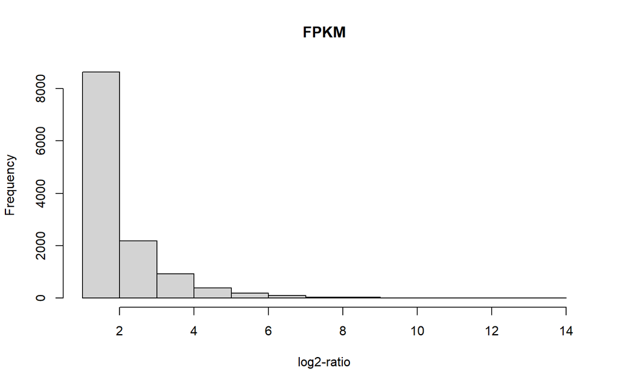

```r
hist(log2(countsFPKM[,1]+2), xlab="log2-ratio", main="FPKM")
```

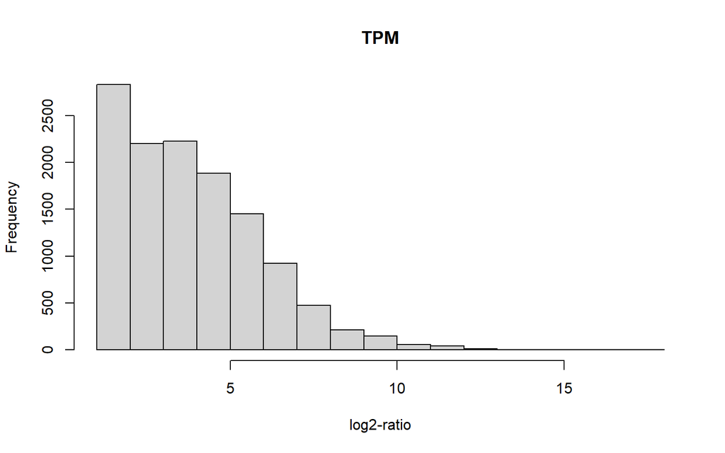

```r
hist(log2(countsTPM[,1]+2), xlab="log2-ratio", main="TPM")
```

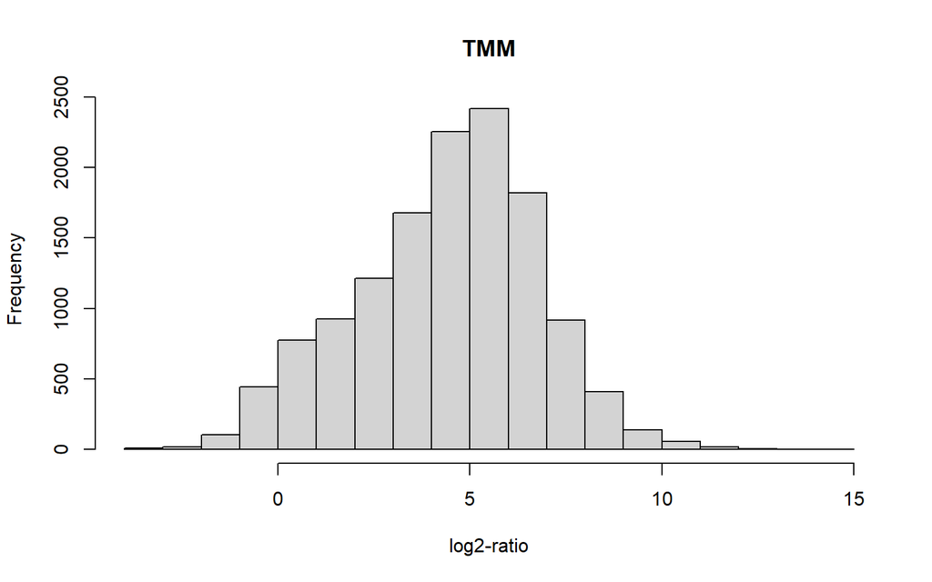

```r
hist(countsTMM[,1], xlab="log2-ratio", main="TMM")
```

# 4 **Sample aggregation**

**1. Hierarchical clustering**

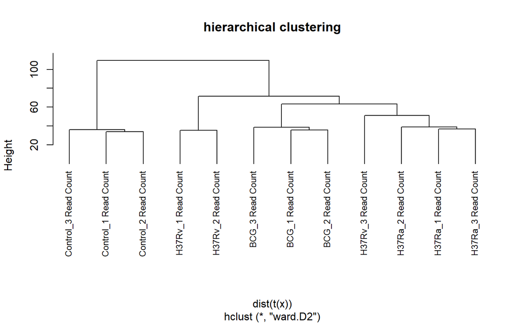

```r
x<-countsTMM

#Euclidean distance
clust.cor.ward <- hclust(dist(t(x)),method="ward.D2")
plot(clust.cor.ward, main="hierarchical clustering", hang=-1,cex=0.8)
```

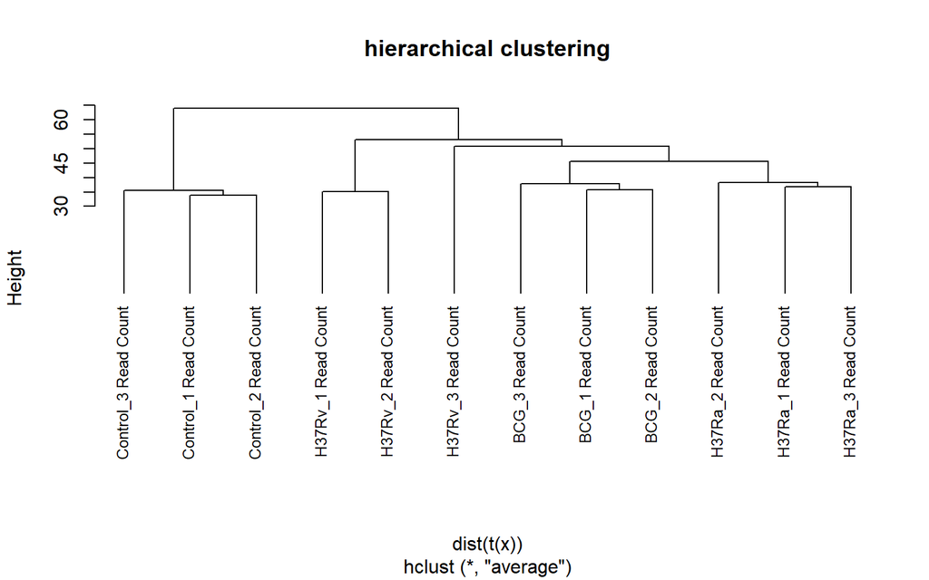

```r
clust.cor.average <- hclust(dist(t(x)),method="average")
plot(clust.cor.average, main="hierarchical clustering", hang=-1,cex=0.8)
```

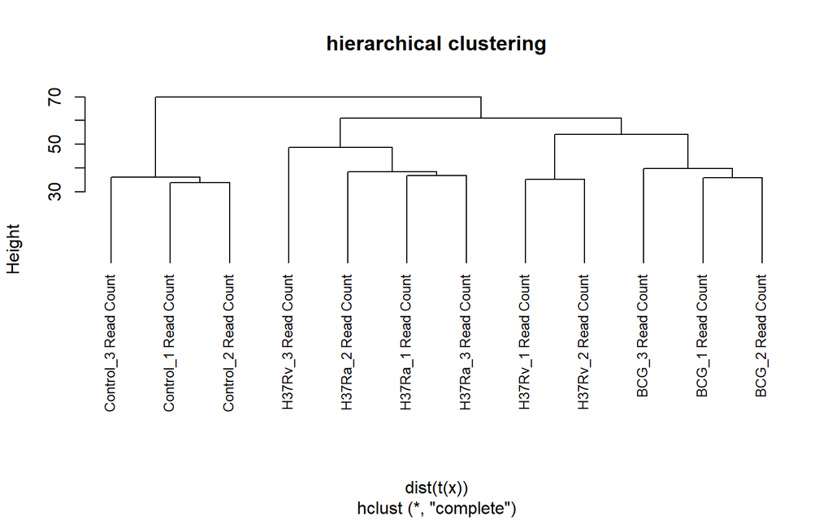

```r
clust.cor.average <- hclust(dist(t(x)),method="complete")
plot(clust.cor.average, main="hierarchical clustering", hang=-1,cex=0.8)
```

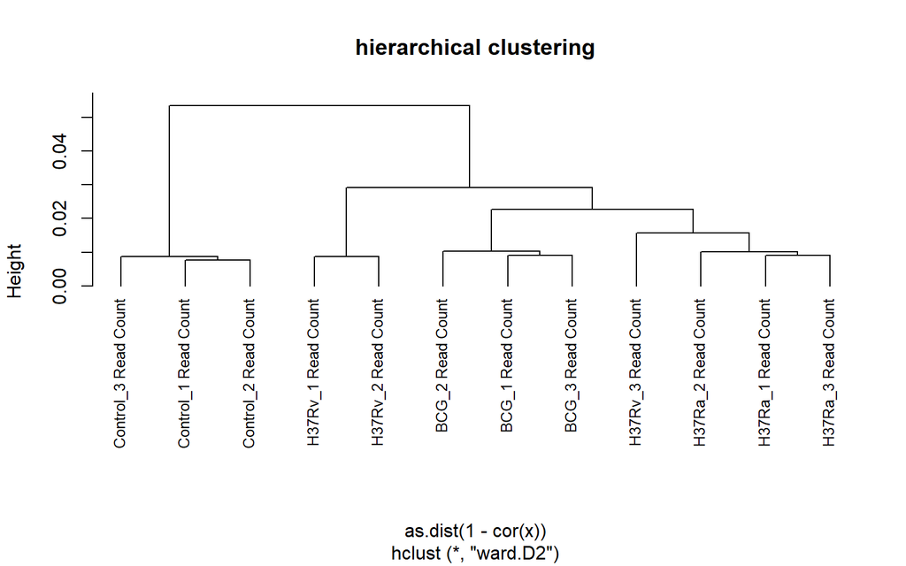

```r
#Correlation based distance
clust.cor.ward <- hclust(as.dist(1-cor(x)),method="ward.D2")
plot(clust.cor.ward, main="hierarchical clustering", hang=-1,cex=0.8)
```

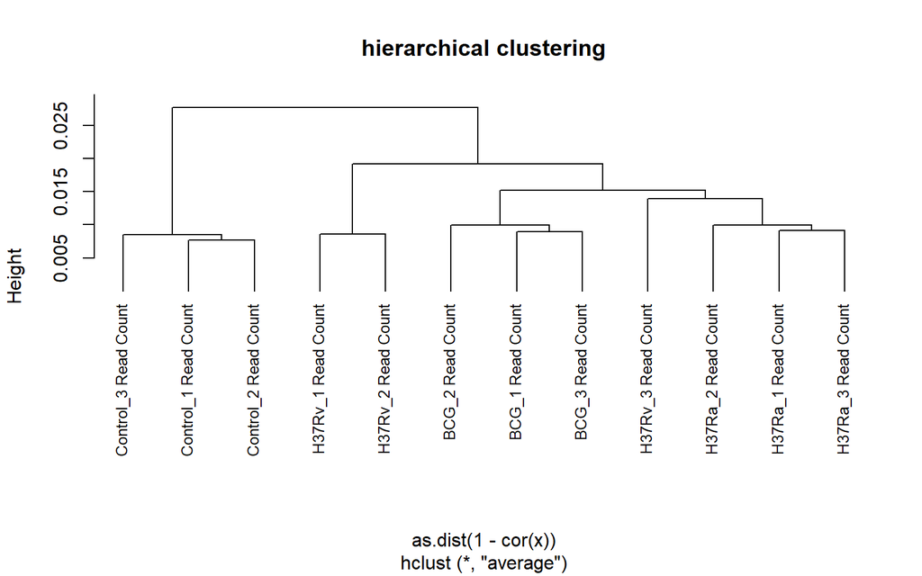

```r
clust.cor.average<- hclust(as.dist(1-cor(x)),method="average")
plot(clust.cor.average, main="hierarchical clustering", hang=-1,cex=0.8)
```

**Comment:** The sample aggregation is quite homogeneous and samples aggregate by M.tuberculosis strains samples. Notably, sample H37Rv_3 separately aggregates from the rest of repeats for the strain.

**2. PCA**

```r
summary(pca.filt <- prcomp(t(x), scale=T ))
```

```
## Importance of components:
##                            PC1     PC2     PC3      PC4      PC5      PC6
## Standard deviation     66.7102 54.3152 38.8500 30.54264 25.05395 23.98454
## Proportion of Variance  0.3372  0.2236  0.1144  0.07069  0.04757  0.04359
## Cumulative Proportion   0.3372  0.5608  0.6752  0.74587  0.79344  0.83704
##                             PC7      PC8      PC9     PC10     PC11      PC12
## Standard deviation     22.26391 21.40837 20.49717 19.96940 19.43119 2.385e-13
## Proportion of Variance  0.03756  0.03473  0.03184  0.03022  0.02861 0.000e+00
## Cumulative Proportion   0.87460  0.90933  0.94117  0.97139  1.00000 1.000e+00
```

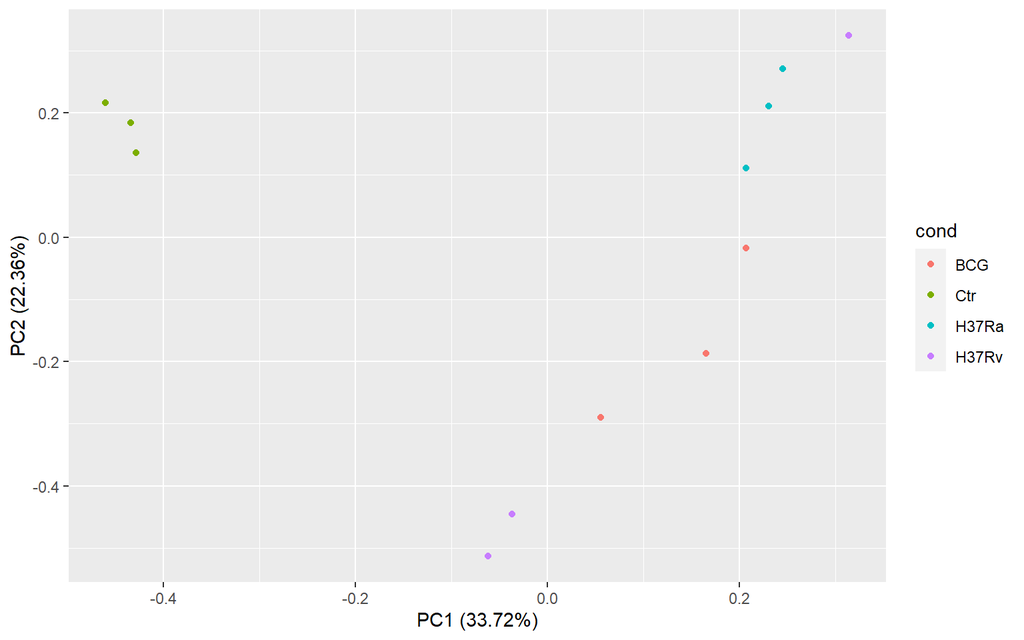

```r
autoplot(pca.filt, data=phenoN, colour="cond")
```

**Comment:** A two-dimensional scatter plot of PCA represents the relationships between samples of macrophages - infected and uninfected. The X-axis corresponds to PC1 (PCA Component 1), capturing 33.72% of the variance, while the Y-axis represents PC2 (PCA Component 2) with 22.36% variance. Control samples are clustered separately from other groups. The single repeat for the H37Rv_3 condition is distinctively located apart from the remaining two repeats for the strain. This separation appears to be meaningful for the experiment, and accordingly, we have decided to keep the sample.

# 5 **Differential expression analysis**

**voom + limma**

```r
dim(countsF)
```

```
## [1] 13196    12
```

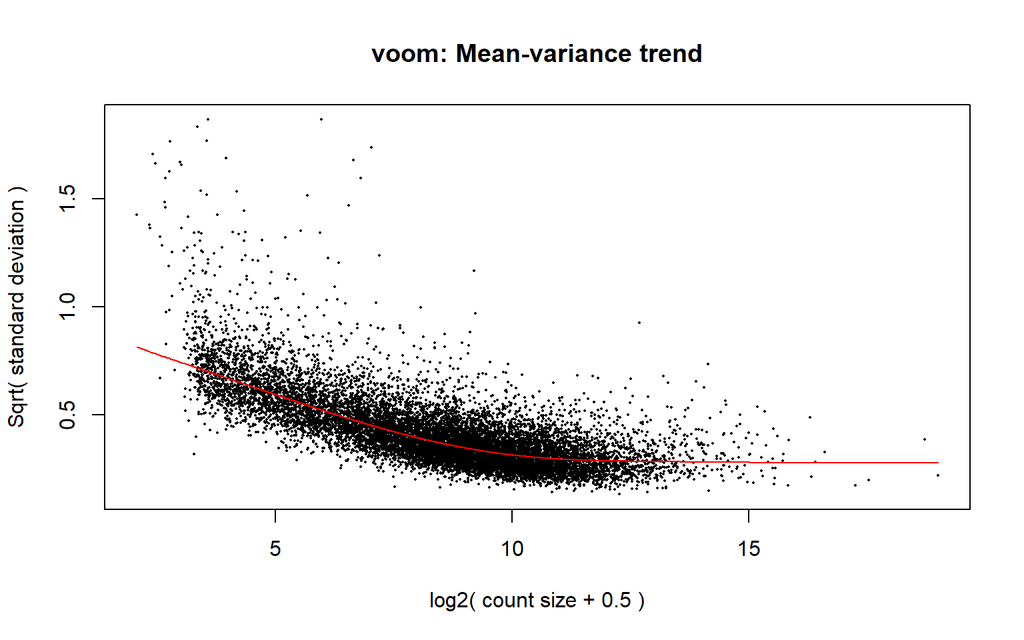

```r
cond <- as.factor(phenoN$cond)

# design matrix
design <- model.matrix(~0+cond)
rownames(design) <- phenoN$sampleName
colnames(design) <- gsub("cond", "", colnames(design))

voom.res <- voom(countsF, design, plot = T)
```

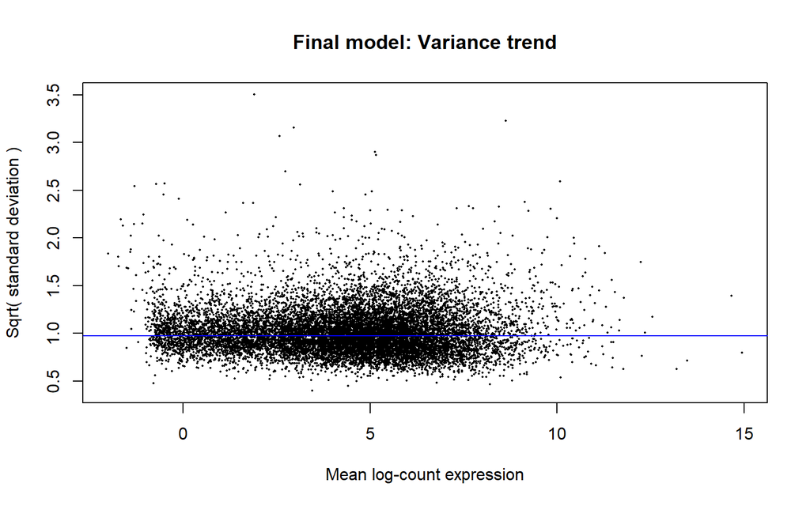

```r
# model fit
fit <- lmFit(voom.res, design)

# contrasts
contrast.matrix <- makeContrasts(con1=Ctr-BCG,
                                 con2=Ctr-H37Ra,
                                 con3=Ctr-H37Rv,
                                 levels = design)

# contrasts fit and Bayesian adjustment
fit2 <- contrasts.fit(fit, contrast.matrix)
fite <- eBayes(fit2)

#plot final model
plotSA(fite, main="Final model: Variance trend", ylab = "Sqrt( standard deviation )", xlab = "Mean log-count expression")
```

```r
# summary
summary(decideTests(fite, method = "separate"))
```

```
##        con1 con2 con3
## Down   2282 2082 1879
## NotSig 8643 8313 9333
## Up     2271 2801 1984
```

```r
#global model
top.table <- topTable(fite, number = Inf, adjust = "fdr")
```

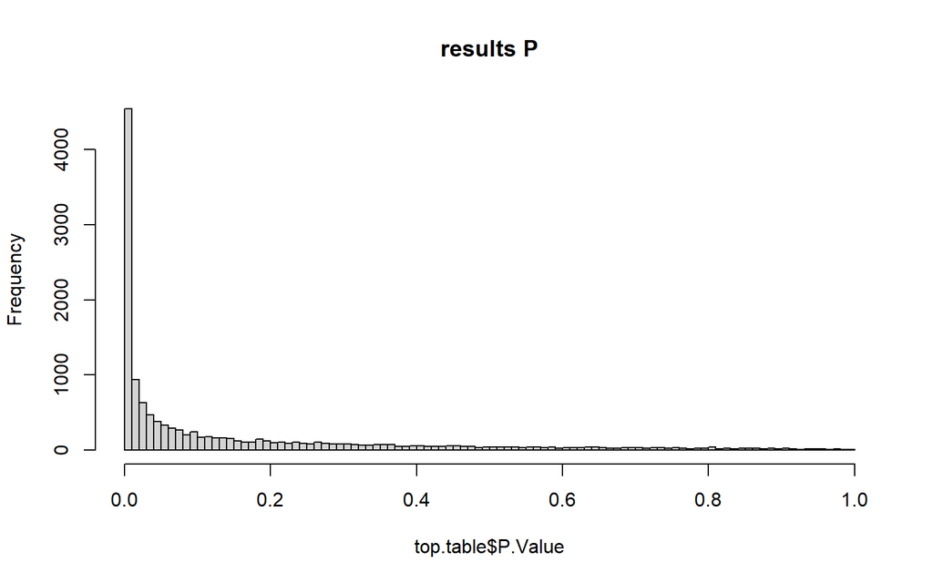

```r
hist(top.table$P.Value, breaks = 100, main = "results P")
```

**Volcano plot**

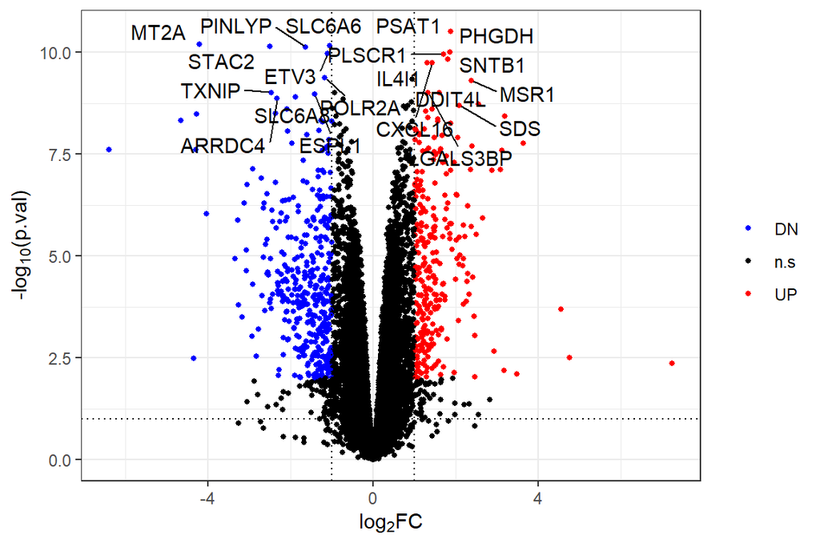

```r
# Volcano plot
colorS <- c("UP" = "red", "DN" = "blue", "n.s" = "black")
showGenes <- 20

# 'fite' is DESeqDataSet object
dataV1 <- topTable(fite, n = Inf, coef = "con1", adjust = "fdr")

dataV1 <- dataV1 %>%
  mutate(sig = ifelse(P.Value < 0.01 & logFC > 1, "UP", ifelse(P.Value < 0.01 & logFC < (-1), "DN", "n.s")))

p <- ggplot(data = dataV1, aes(x = logFC, y = -log10(P.Value))) +
  geom_point(alpha = 1, size = 1, aes(col = sig)) +
  scale_color_manual(values = colorS) +
  xlab(expression("log"[2] * "FC")) + ylab(expression("-log"[10] * "(p.val)")) +
  labs(col = " ") +
  geom_vline(xintercept = 1, linetype = "dotted") +
  geom_vline(xintercept = -1, linetype = "dotted") +
  geom_hline(yintercept = -log10(0.1), linetype = "dotted") +
  theme_bw()

p <- p + geom_text_repel(
  data = head(dataV1[dataV1$sig != "n.s", ], showGenes),
  aes(label = ID),  # hgnc_symbol instead of gene
  max.overlaps = Inf
)

print(p)
```

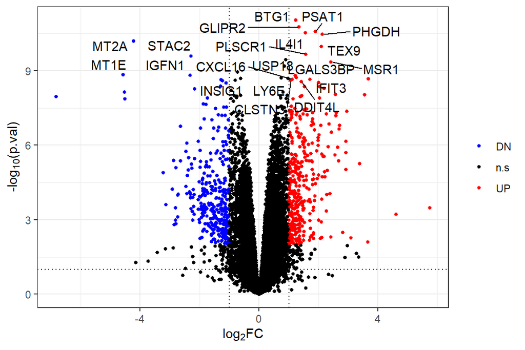

```r
# Volcano plot
colorS <- c("UP" = "red", "DN" = "blue", "n.s" = "black")
showGenes <- 20

# 'fite' is DESeqDataSet object
dataV2 <- topTable(fite, n = Inf, coef = "con2", adjust = "fdr")

dataV2 <- dataV2 %>%
  mutate(sig = ifelse(P.Value < 0.01 & logFC > 1, "UP", ifelse(P.Value < 0.01 & logFC < (-1), "DN", "n.s")))

p <- ggplot(data = dataV2, aes(x = logFC, y = -log10(P.Value))) +
  geom_point(alpha = 1, size = 1, aes(col = sig)) +
  scale_color_manual(values = colorS) +
  xlab(expression("log"[2] * "FC")) + ylab(expression("-log"[10] * "(p.val)")) +
  labs(col = " ") +
  geom_vline(xintercept = 1, linetype = "dotted") +
  geom_vline(xintercept = -1, linetype = "dotted") +
  geom_hline(yintercept = -log10(0.1), linetype = "dotted") +
  theme_bw()

p <- p + geom_text_repel(
  data = head(dataV2[dataV2$sig != "n.s", ], showGenes),
  aes(label = ID),  # hgnc_symbol instead of gene
  max.overlaps = Inf
)

print(p)
```

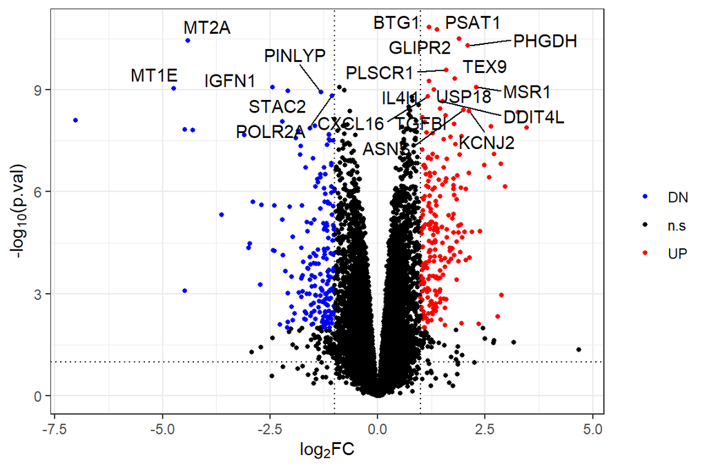

```r
# Volcano plot
colorS <- c("UP" = "red", "DN" = "blue", "n.s" = "black")
showGenes <- 20

# 'fite' is DESeqDataSet object
dataV3 <- topTable(fite, n = Inf, coef = "con3", adjust = "fdr")

dataV3 <- dataV3 %>%
  mutate(sig = ifelse(P.Value < 0.01 & logFC > 1, "UP", ifelse(P.Value < 0.01 & logFC < (-1), "DN", "n.s")))

p <- ggplot(data = dataV3, aes(x = logFC, y = -log10(P.Value))) +
  geom_point(alpha = 1, size = 1, aes(col = sig)) +
  scale_color_manual(values = colorS) +
  xlab(expression("log"[2] * "FC")) + ylab(expression("-log"[10] * "(p.val)")) +
  labs(col = " ") +
  geom_vline(xintercept = 1, linetype = "dotted") +
  geom_vline(xintercept = -1, linetype = "dotted") +
  geom_hline(yintercept = -log10(0.1), linetype = "dotted") +
  theme_bw()

p <- p + geom_text_repel(
  data = head(dataV3[dataV3$sig != "n.s", ], showGenes),
  aes(label = ID),  # hgnc_symbol instead of gene
  max.overlaps = Inf
)

print(p)
```

**Heatmaps**

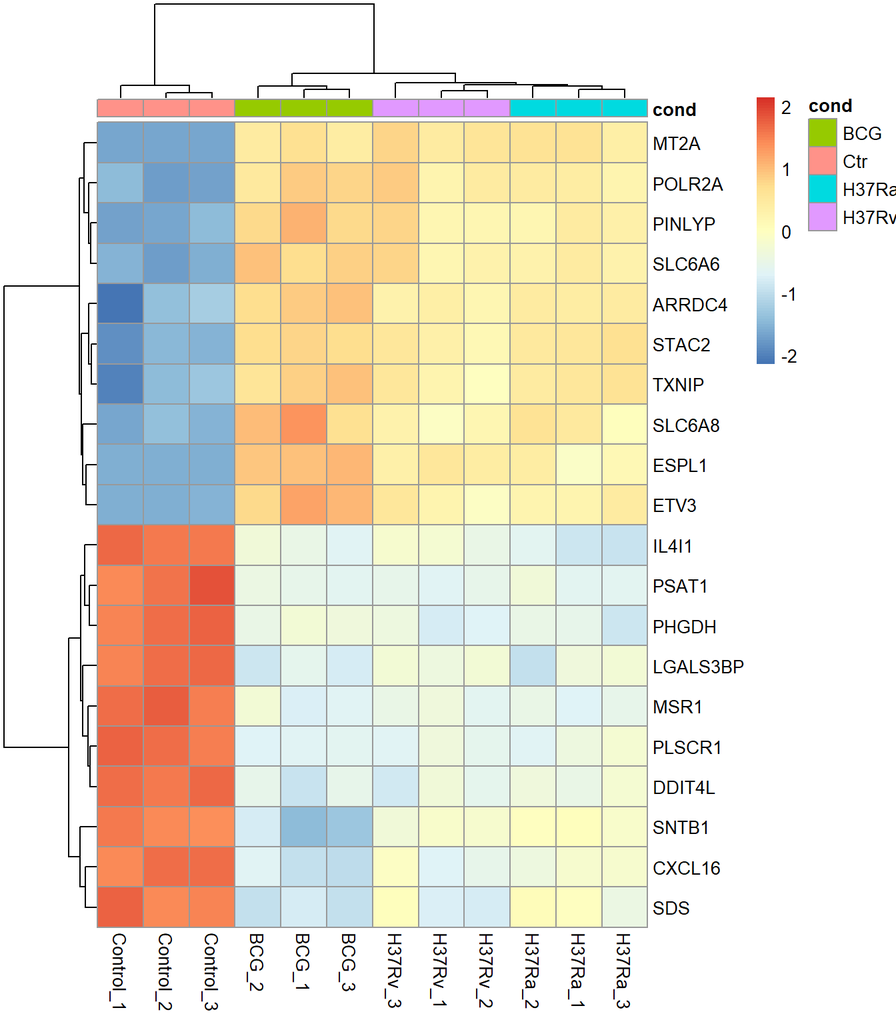

```r
#Heatmap
t1 <- limma::topTable(fite, n = Inf, coef = "con1", adjust = "fdr")
res1 <- t1[t1$P.Value<0.01 & abs(t1$logFC) > 1,]

top_genes <- res1[res1$P.Value < 0.01 & abs(res1$logFC) > 1, ]

# Select the top 20 most significant genes
top20_genes <- head(top_genes, 20)

data.clus1 <- countsTMM[rownames(countsTMM) %in% top20_genes$ID, ]

#to change column names
custom_sample_names <- c(
  "Control_1 Read Count", "Control_2 Read Count", "Control_3 Read Count",
  "H37Rv_1 Read Count", 'H37Rv_2 Read Count', 'H37Rv_3 Read Count',
  'H37Ra_1 Read Count', 'H37Ra_2 Read Count', 'H37Ra_3 Read Count',
  'BCG_1 Read Count', 'BCG_2 Read Count', 'BCG_3 Read Count'
)

# Update column names without 'Read Count'
colnames(data.clus1) <- sub(" Read Count", "", custom_sample_names)

# Create a data frame for conditions
cond.df <- as.data.frame(cond)
rownames(cond.df) <- colnames(data.clus1)

# Set up pheatmap parameters
pheatmap(
  data.clus1,
  scale = "row",
  show_rownames = TRUE,
  annotation_col = cond.df,

)
```

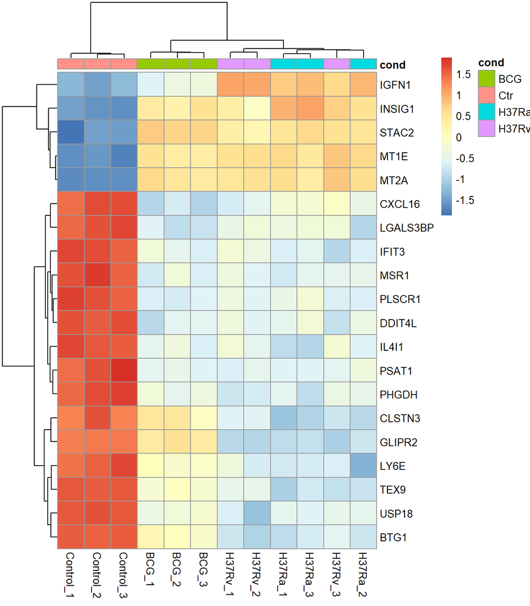

```r
#Heatmap
t2 <- topTable(fite, n = Inf, coef = "con2", adjust = "fdr")
res2 <- t2[t2$P.Value<0.01 & abs(t2$logFC) > 1,]

top_genes2 <- res2[res2$P.Value < 0.01 & abs(res2$logFC) > 1, ]

# Select the top 20 most significant genes
top20_genes2 <- head(top_genes2, 20)

data.clus2 <- countsTMM[rownames(countsTMM) %in% top20_genes2$ID, ]

#to change column names
custom_sample_names <- c(
  "Control_1 Read Count", "Control_2 Read Count", "Control_3 Read Count",
  "H37Rv_1 Read Count", 'H37Rv_2 Read Count', 'H37Rv_3 Read Count',
  'H37Ra_1 Read Count', 'H37Ra_2 Read Count', 'H37Ra_3 Read Count',
  'BCG_1 Read Count', 'BCG_2 Read Count', 'BCG_3 Read Count'
)

# Update column names without 'Read Count'
colnames(data.clus2) <- sub(" Read Count", "", custom_sample_names)

# Create a data frame for conditions
cond.df <- as.data.frame(cond)
rownames(cond.df) <- colnames(data.clus2)

# Set up pheatmap parameters
pheatmap(
  data.clus2,
  scale = "row",
  show_rownames = TRUE,
  annotation_col = cond.df,


)
```

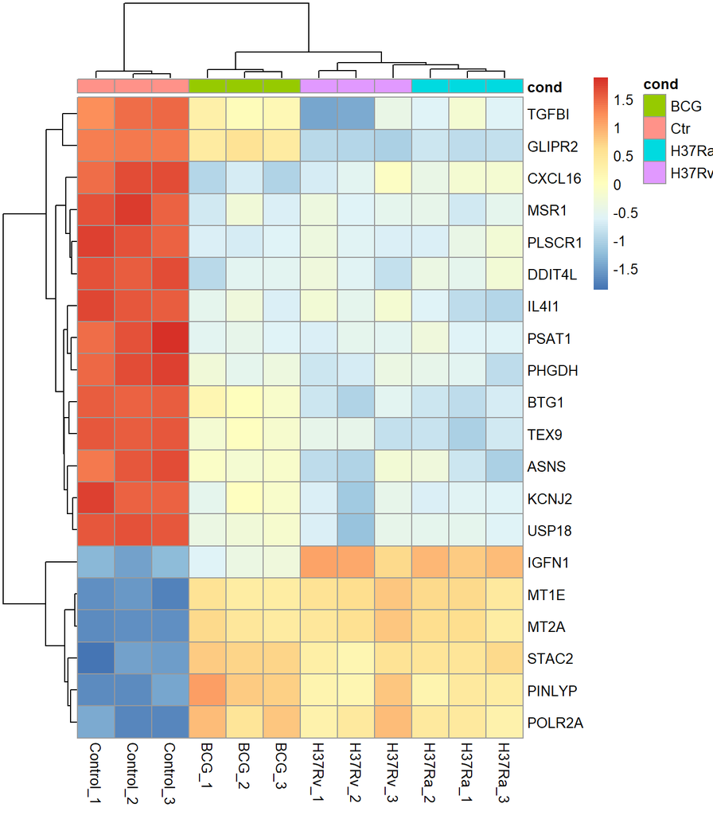

```r
#Heatmap
t3 <- topTable(fite, n = Inf, coef = "con3", adjust = "fdr")
res3 <- t3[t3$P.Value<0.01 & abs(t3$logFC) > 1,]

top_genes3 <- res3[res3$P.Value < 0.01 & abs(res3$logFC) > 1, ]

# Select the top 20 most significant genes
top20_genes3 <- head(top_genes3, 20)

data.clus3 <- countsTMM[rownames(countsTMM) %in% top20_genes3$ID, ]

#to change column names
custom_sample_names <- c(
  "Control_1 Read Count", "Control_2 Read Count", "Control_3 Read Count",
  "H37Rv_1 Read Count", 'H37Rv_2 Read Count', 'H37Rv_3 Read Count',
  'H37Ra_1 Read Count', 'H37Ra_2 Read Count', 'H37Ra_3 Read Count',
  'BCG_1 Read Count', 'BCG_2 Read Count', 'BCG_3 Read Count'
)

# Update column names without 'Read Count'
colnames(data.clus3) <- sub(" Read Count", "", custom_sample_names)

# Create a data frame for conditions
cond.df <- as.data.frame(cond)
rownames(cond.df) <- colnames(data.clus3)

# Set up pheatmap parameters
pheatmap(
  data.clus3,
  scale = "row",
  show_rownames = TRUE,
  annotation_col = cond.df,


)
```

**Comment:** Heatmaps are frequently used to grasp patterns of gene expression and to observe how these patterns vary across experimental conditions. Here, we generate heatmaps based on the expression levels of the top 20 most significant genes (p < 0.01) identified in a differential expression analysis. Each row corresponds to a gene, and each column corresponds to a sample. The color intensity represents the expression level of each gene, with a color scale indicating high or low expression. The row names (gene names) are displayed on the side. The column annotations provide information about the conditions of the samples. For our example, changing the conditions in the cond variable affects the appearance of the heatmap as the gene expression patterns are not similar across different conditions.

# 6 **References**

Dataset Link: Pu, W., Zhao, C., Wazir, J., Su, Z., Niu, M., Song, S., … Wang, H. (2021). Comparative transcriptomic analysis of THP-1-derived macrophages infected with Mycobacterium tuberculosis H37Rv, H37Ra and BCG. Gene Expression Omnibus (GEO) accession GSE162729.

Journal Article: Pu, W., Zhao, C., Wazir, J., Su, Z., Niu, M., Song, S., … Wang, H. (2021). Comparative transcriptomic analysis of THP-1-derived macrophages infected with Mycobacterium tuberculosis H37Rv, H37Ra and BCG. Journal of Cell and Molecular Medicine, 25(22), 10504-10520. https://doi.org/10.1111/jcmm.16980.

Tutorial: Nonell, L. (2023) ‘RNA-seq data analysis’, Tutorial for master’s students in Omics Data Analysis at UVIC-UCC. Available at: https://aules.uvic.cat/pluginfile.php/1578837/mod_resource/content/3/RNAseq.html (Accessed: [17 Dec 2023 ]).